# Part I - How Various loan data features affect borrowers APR

## Introduction

> This data set contains 113,937 loans with 81 variables on each loan, including loan amount, borrower rate (or interest rate), current loan status, borrower income, and many others. the loans were given by proser loan company

## Preliminary Wrangling

```python
# import all packages and set plots to be embedded inline
import numpy as np
import pandas as pd
import matplotlib.pyplot as plt
import seaborn as sb

%matplotlib inline
```

### Loading data

```python
df = pd.read_csv('prosperLoanData.csv')
df.shape
```

```
(113937, 81)
```

```python
df.info()
```

```
<class 'pandas.core.frame.DataFrame'>
RangeIndex: 113937 entries, 0 to 113936
Data columns (total 81 columns):
 #   Column                               Non-Null Count   Dtype
---  ------                               --------------   -----
 0   ListingKey                           113937 non-null  object
 1   ListingNumber                        113937 non-null  int64
 2   ListingCreationDate                  113937 non-null  object
 3   CreditGrade                          28953 non-null   object
 4   Term                                 113937 non-null  int64
 5   LoanStatus                           113937 non-null  object
 6   ClosedDate                           55089 non-null   object
 7   BorrowerAPR                          113912 non-null  float64
 8   BorrowerRate                         113937 non-null  float64
 9   LenderYield                          113937 non-null  float64
```

[output cut: 73 more lines]

- Dataset contains 113937 rows, and 81 columns however, some of these columns are not necessary for my desired analysis therefore I would rather exteact the desired aspect of the data

```python
# Extracting desired columns and droping na values
cols = ['Term', 'EmploymentStatus',
        'DebtToIncomeRatio', 'StatedMonthlyIncome',
       'LoanOriginalAmount','ProsperScore', 'BorrowerAPR',]
loan_sub = df[cols].dropna()
print(loan_sub.shape)
loan_sub.head()
```

```
(77557, 7)
```

|  | Term | EmploymentStatus | DebtToIncomeRatio | StatedMonthlyIncome | LoanOriginalAmount | ProsperScore | BorrowerAPR |
| --- | --- | --- | --- | --- | --- | --- | --- |
| 1 | 36 | Employed | 0.18 | 6125.000000 | 10000 | 7.0 | 0.12016 |
| 3 | 36 | Employed | 0.15 | 2875.000000 | 10000 | 9.0 | 0.12528 |
| 4 | 36 | Employed | 0.26 | 9583.333333 | 15000 | 4.0 | 0.24614 |
| 5 | 60 | Employed | 0.36 | 8333.333333 | 15000 | 10.0 | 0.15425 |
| 6 | 36 | Employed | 0.27 | 2083.333333 | 3000 | 2.0 | 0.31032 |

```python
loan_sub.info()
```

```
<class 'pandas.core.frame.DataFrame'>
Int64Index: 77557 entries, 1 to 113936
Data columns (total 7 columns):
 #   Column               Non-Null Count  Dtype
---  ------               --------------  -----
 0   Term                 77557 non-null  int64
 1   EmploymentStatus     77557 non-null  object
 2   DebtToIncomeRatio    77557 non-null  float64
 3   StatedMonthlyIncome  77557 non-null  float64
 4   LoanOriginalAmount   77557 non-null  int64
 5   ProsperScore         77557 non-null  float64
 6   BorrowerAPR          77557 non-null  float64
dtypes: float64(4), int64(2), object(1)
memory usage: 4.7+ MB
```

### What is/are the main feature(s) of interest in your dataset?

> I am interested in knowing What factors affect the borrower’s APR (Annual percentage rate) and how?

### What features in the dataset do you think will help support your investigation into your feature(s) of interest?

> I suspect the following factors will affect the borrowers APR:
> - Term
> - EmploymentStatus
> - DebtToIncomeRatio
> - StatedMonthlyIncome
> - LoanOriginalAmount
> - ProsperScore
> - BorrowerAPR

## Univariate Exploration

### BorrowerAPR

> I will start by looking at the main varibale of interest, **BorrowerAPR**

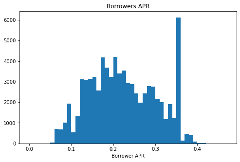

```python
# Ploting a histogram of borrowers APR
bins = np.arange(0, loan_sub.BorrowerAPR.max()+0.05, 0.01)
plt.figure(figsize=[8, 5])
plt.hist(data = loan_sub, x = 'BorrowerAPR', bins = bins);
plt.xlabel('Borrower APR')
plt.title('Borrowers APR');
```

- The Borrowers APR seem to be multimodal with a high spike around 0.37

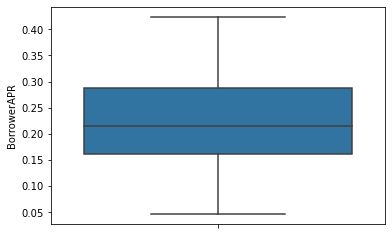

```python
# Box plot for borrowers APR
sb.boxplot(data=loan_sub, y='BorrowerAPR');
```

### Employment status

> - Next I look that the employment status column
> - Since this is a categorical data I will use a bar chart to visualize It

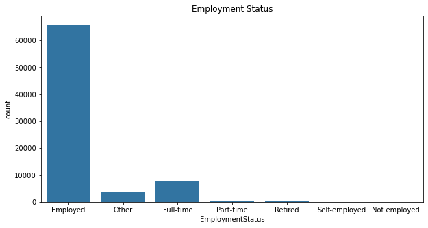

```python
# Plotting a bar chart for the employment status column
plt.figure(figsize=(10,5))
default_color = sb.color_palette()[0]
sb.countplot(data=loan_sub, x='EmploymentStatus', color = default_color)
plt.title('Employment Status');
```

- Most borrowers are employed over 50%

### Loan amount

> - Since this is a continious data I would use a histogram

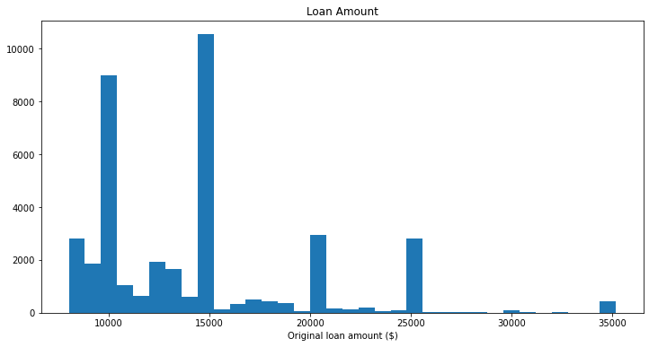

```python
# Ploting a hsitogram for loan amount
bins = np.arange(8000, loan_sub.LoanOriginalAmount.max()+800, 800)
plt.figure(figsize=[12, 6])
plt.hist(data = loan_sub, x = 'LoanOriginalAmount', bins=bins);
plt.xlabel('Original loan amount ($)')
plt.title('Loan Amount');
```

```python
loan_sub.LoanOriginalAmount.describe()
```

```
count    77557.000000
mean      9269.314208
std       6398.380615
min       1000.000000
25%       4000.000000
50%       8000.000000
75%      14500.000000
max      35000.000000
Name: LoanOriginalAmount, dtype: float64
```

### Debt to Income Ratio

> - Again I would use a histogram plot since this is a continious data

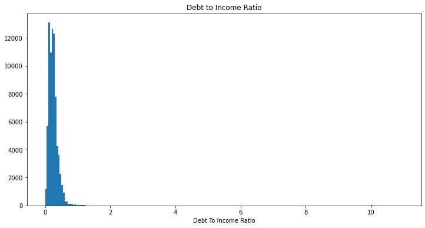

```python
# Ploting a histigram for debt to income ratio
bins = np.arange(0, loan_sub.DebtToIncomeRatio.max()+1, 0.05)
plt.figure(figsize=[12, 6])
plt.hist(data = loan_sub, x = 'DebtToIncomeRatio',bins=bins);
plt.xlabel('Debt To Income Ratio')
plt.title('Debt to Income Ratio');
```

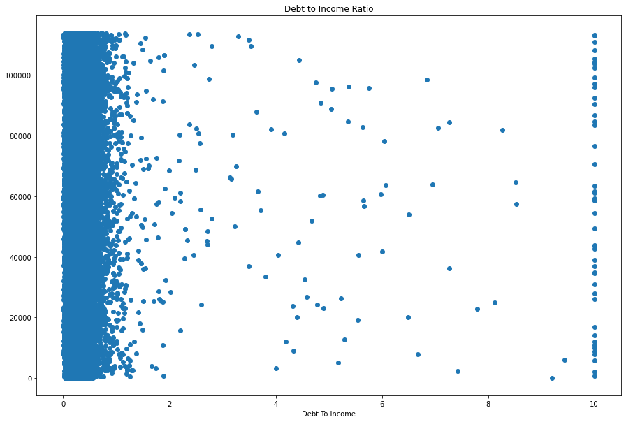

```python
# Ploting a scattered plot to get further insight on the spread of data
plt.figure(figsize=[15,10])
plt.scatter(loan_sub['DebtToIncomeRatio'],loan_sub.index)
plt.title('Debt to Income Ratio')
plt.xlabel('Debt To Income');
```

```python
loan_sub[loan_sub.DebtToIncomeRatio >10]
```

|  | Term | EmploymentStatus | DebtToIncomeRatio | StatedMonthlyIncome | LoanOriginalAmount | ProsperScore | BorrowerAPR |
| --- | --- | --- | --- | --- | --- | --- | --- |
| 626 | 36 | Employed | 10.01 | 3.833333 | 2000 | 4.0 | 0.35797 |
| 2155 | 36 | Full-time | 10.01 | 17083.333333 | 13500 | 8.0 | 0.09643 |
| 5806 | 36 | Employed | 10.01 | 5.833333 | 2000 | 3.0 | 0.35797 |
| 7871 | 36 | Employed | 10.01 | 3.000000 | 4000 | 4.0 | 0.35797 |
| 8748 | 36 | Employed | 10.01 | 1.833333 | 3000 | 6.0 | 0.35858 |
| 10018 | 36 | Employed | 10.01 | 15.000000 | 3000 | 2.0 | 0.32538 |
| 10969 | 36 | Employed | 10.01 | 2.500000 | 4000 | 2.0 | 0.35356 |
| 12013 | 60 | Employed | 10.01 | 4.500000 | 10000 | 5.0 | 0.31375 |
| 14126 | 60 | Employed | 10.01 | 2.916667 | 15000 | 7.0 | 0.27554 |
| 16849 | 36 | Employed | 10.01 | 4.333333 | 10000 | 5.0 | 0.31790 |
| 26112 | 36 | Full-time | 10.01 | 2.416667 | 2200 | 4.0 | 0.35643 |
| 27865 | 36 | Employed | 10.01 | 2.333333 | 2000 | 4.0 | 0.35797 |
| 30827 | 36 | Employed | 10.01 | 1.416667 | 2500 | 6.0 | 0.33553 |
| 34600 | 36 | Employed | 10.01 | 6.250000 | 4000 | 3.0 | 0.35797 |
| 34883 | 36 | Other | 10.01 | 2.666667 | 14500 | 6.0 | 0.23939 |
| 36933 | 36 | Full-time | 10.01 | 2.416667 | 4000 | 3.0 | 0.35356 |
| 38902 | 60 | Employed | 10.01 | 3.333333 | 6000 | 5.0 | 0.20358 |
| 42606 | 60 | Employed | 10.01 | 3.750000 | 7000 | 6.0 | 0.31375 |
| 43492 | 60 | Employed | 10.01 | 3.083333 | 5000 | 8.0 | 0.20358 |
| 43878 | 36 | Employed | 10.01 | 2.916667 | 2000 | 4.0 | 0.35356 |
| 49287 | 60 | Other | 10.01 | 3.000000 | 5000 | 6.0 | 0.20705 |
| 54378 | 36 | Employed | 10.01 | 3.416667 | 4000 | 7.0 | 0.34045 |
| 58658 | 36 | Employed | 10.01 | 5.416667 | 4000 | 2.0 | 0.35643 |
| 58764 | 36 | Employed | 10.01 | 83.333333 | 6000 | 6.0 | 0.33097 |
| 59341 | 36 | Employed | 10.01 | 2.916667 | 2100 | 4.0 | 0.35797 |
| 61112 | 60 | Employed | 10.01 | 4.333333 | 8550 | 5.0 | 0.32958 |
| 61628 | 36 | Employed | 10.01 | 0.250000 | 4000 | 1.0 | 0.34045 |
| 63426 | 36 | Employed | 10.01 | 7.083333 | 4000 | 3.0 | 0.35797 |
| 70679 | 36 | Employed | 10.01 | 2.500000 | 4000 | 4.0 | 0.35797 |
| 76642 | 36 | Full-time | 10.01 | 2.416667 | 6000 | 6.0 | 0.18316 |
| 83402 | 36 | Other | 10.01 | 3.333333 | 3000 | 3.0 | 0.35797 |
| 84621 | 36 | Employed | 10.01 | 291.666667 | 4000 | 2.0 | 0.35643 |
| 86734 | 12 | Employed | 10.01 | 3.750000 | 10000 | 8.0 | 0.18192 |
| 90410 | 36 | Employed | 10.01 | 2.916667 | 4000 | 5.0 | 0.35797 |
| 92399 | 36 | Employed | 10.01 | 83.333333 | 7500 | 1.0 | 0.35244 |
| 95890 | 36 | Employed | 10.01 | 3.000000 | 5225 | 6.0 | 0.15324 |
| 97141 | 36 | Other | 10.01 | 87.333333 | 2000 | 3.0 | 0.35285 |
| 99260 | 36 | Employed | 10.01 | 5.833333 | 8000 | 6.0 | 0.30532 |
| 102466 | 36 | Employed | 10.01 | 3.166667 | 4000 | 3.0 | 0.35356 |
| 103735 | 36 | Employed | 10.01 | 6.083333 | 7500 | 1.0 | 0.35643 |
| 104199 | 36 | Self-employed | 10.01 | 9.416667 | 3000 | 2.0 | 0.30182 |
| 105343 | 36 | Other | 10.01 | 1.916667 | 2500 | 5.0 | 0.35797 |
| 108116 | 36 | Employed | 10.01 | 3.000000 | 6000 | 5.0 | 0.35132 |
| 110912 | 36 | Employed | 10.01 | 1.833333 | 4000 | 8.0 | 0.17359 |
| 113099 | 36 | Employed | 10.01 | 2.083333 | 2000 | 3.0 | 0.33286 |
| 113258 | 60 | Employed | 10.01 | 2.916667 | 4000 | 6.0 | 0.27554 |

### Term

> - Here I would use a bar chart to visualize the term

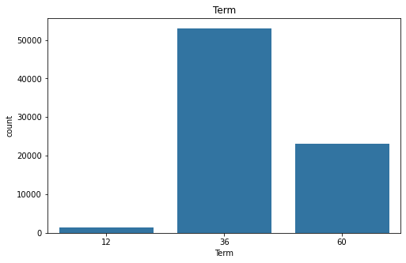

```python
# plotting barchart for term
plt.figure(figsize=(8,5))
default_color = sb.color_palette()[0]
sb.countplot(data=loan_sub, x='Term', color = default_color)
plt.title('Term');
```

- over 50% of the loans have a duration of 36 months

### Monthly Income

> - Being a continous data I woild use a histogram

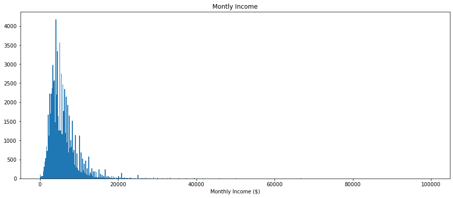

```python
# plotting a histogram for monthly income
bins = np.arange(0, 100000, 200)
plt.figure(figsize=[15, 6])
plt.hist(data = loan_sub, x = 'StatedMonthlyIncome', bins = bins);
plt.xlabel('Monthly Income ($)')
plt.title('Montly Income');
```

```python
loan_sub.StatedMonthlyIncome.max()
```

```
483333.333333
```

```python
loan_sub[loan_sub.StatedMonthlyIncome > 100000]
```

|  | Term | EmploymentStatus | DebtToIncomeRatio | StatedMonthlyIncome | LoanOriginalAmount | ProsperScore | BorrowerAPR |
| --- | --- | --- | --- | --- | --- | --- | --- |
| 8066 | 36 | Employed | 0.00 | 416666.666667 | 2000 | 4.0 | 0.35643 |
| 17411 | 36 | Employed | 0.00 | 483333.333333 | 7500 | 5.0 | 0.35643 |
| 57133 | 36 | Employed | 0.00 | 466666.666667 | 4000 | 5.0 | 0.35643 |
| 80075 | 36 | Employed | 0.05 | 158333.333333 | 25000 | 6.0 | 0.20217 |
| 111265 | 60 | Employed | 0.03 | 108750.000000 | 12765 | 9.0 | 0.20593 |
| 113270 | 36 | Employed | 0.00 | 394400.000000 | 2000 | 6.0 | 0.22712 |

```python
# percentage of borrowers whose monthly income greater than 40k
(loan_sub.StatedMonthlyIncome > 40000).sum()/(loan_sub.shape[0])
```

```
0.0010186056706680247
```

```python
# remove loans with stated monthly income greater than 40k, which are outliers
loan_sub = loan_sub[loan_sub.StatedMonthlyIncome<=40000]
```

```python
loan_sub.StatedMonthlyIncome.describe()
```

```
count    77478.000000
mean      5891.097883
std       3618.658199
min          0.250000
25%       3525.041667
50%       5000.000000
75%       7166.666667
max      39953.333333
Name: StatedMonthlyIncome, dtype: float64
```

### Prosper Score

> - This is a descrete data so I would use a bar chart

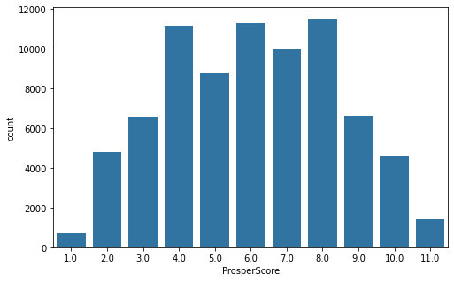

```python
# plotting a bar chart for the Prosper score
plt.figure(figsize=(8,5))
default_color = sb.color_palette()[0]
sb.countplot(data=loan_sub, x='ProsperScore', color = default_color);
```

> - most borrowers have prosper rating of 4,6,8

## Bivariate Exploration

> - First I would look at a general corrolation relationship between all values

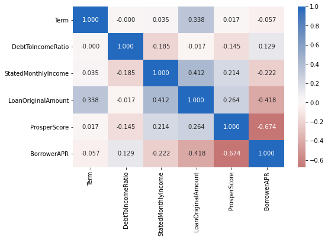

```python
# correlation plot
plt.figure(figsize = [8, 5])
sb.heatmap(loan_sub.corr(), annot = True, fmt = '.3f', cmap = 'vlag_r', center = 0);
```

```python
num_cols = ['DebtToIncomeRatio', 'StatedMonthlyIncome', 'LoanOriginalAmount', 'BorrowerAPR']
cat_cols = ['Term', 'ProsperScore', 'EmploymentStatus',]
```

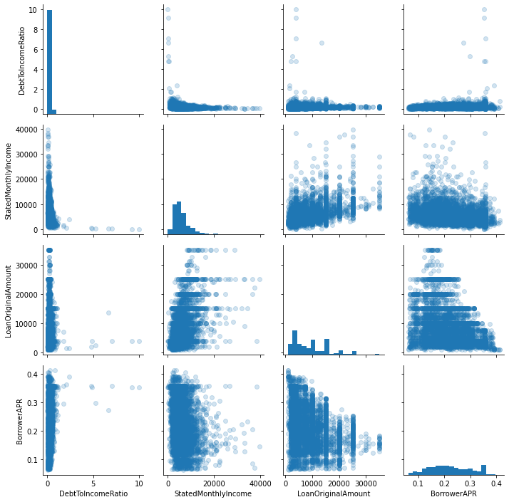

```python
# a pairwise scatter plot
loan_sub_samp = loan_sub.sample(5000)
g = sb.PairGrid(data = loan_sub_samp.dropna(), vars = num_cols)
g = g.map_diag(plt.hist, bins=20)
g.map_offdiag(plt.scatter, alpha=0.2);
```

- The loan amount has a negative corrolation of 0.418 with the borrowersAPR which agrees with the fact that the more the loan amount the lower the borrowersAPR
- The state monthly income has a positive corrolation of 0.412 with the loan amount which is quite expected since the more a person earns the more loan he is able to access

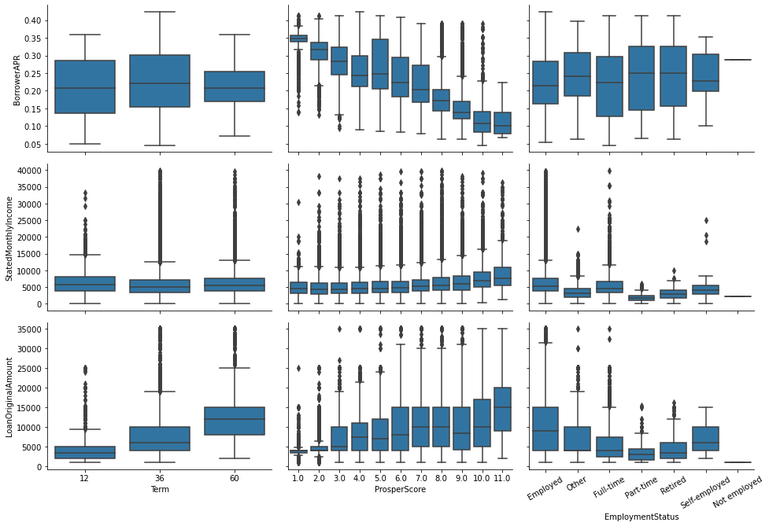

```python
# plot matrix of numeric features against categorical features using a box plot.

def boxgrid(x, y, **kwargs):
    default_color = sb.color_palette()[0]
    sb.boxplot(x=x, y=y, color = default_color);

plt.figure(figsize = [10, 10])
g = sb.PairGrid(data = loan_sub, y_vars = ['BorrowerAPR', 'StatedMonthlyIncome', 'LoanOriginalAmount'],
                x_vars = cat_cols, height = 3, aspect = 1.5);
g.map(boxgrid);
plt.xticks(rotation=30);
```

- The longer the loan term the more the loan amount
- The lower the prosper score the higer the borrowers APR
- The higer the prosper score the higer the monthly income
- Borrowers who are employed and self-employed have more loan amount and monthly income compared to not employed or part-time

#### Relationship between categorical variables

**Prosper rating vs term**

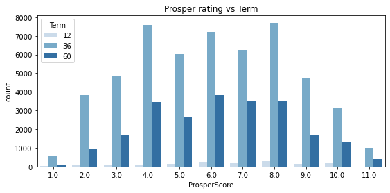

```python
# Prosper rating vs term
plt.figure(figsize=[9,4])
sb.countplot(data = loan_sub, x = 'ProsperScore', hue = 'Term', palette = 'Blues')
plt.title('Prosper rating vs Term');
```

- For all the various actegory of the prosper score 36 is the highest term
- For prosper rating of 1 and 11 there is no 12 term

**Employment status vs. Term**

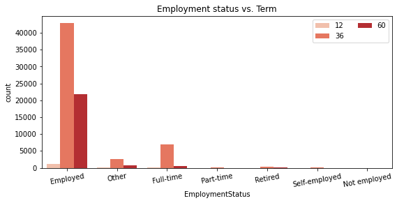

```python
# employment status vs. term
plt.figure(figsize=[9,4])
sb.countplot(data = loan_sub, x = 'EmploymentStatus', hue = 'Term', palette = 'Reds')
plt.legend(loc = 1, ncol = 2)
plt.xticks(rotation=10)
plt.title('Employment status vs. Term');
```

- Generally 36 months is the highest term for all the groups of employment status
- There is no/negligable data for 12 months for the not avalible part-time and retired category of employment status

**Prosper score vs. employment status**

[figure not shown]

```python
# Prosper score vs. employment status
plt.figure(figsize=[9,4])
sb.countplot(data = loan_sub, x = 'EmploymentStatus', hue = 'ProsperScore', palette = 'Greens')
plt.legend(loc = 1, ncol = 2); # re-arrange legend to remove overlapping
plt.xticks(rotation=10)
plt.title('Prosper score vs. Employment status');
```

- Borrowers who are employed has more records with the higest being those with prosper rating of 4.0

**Borrowers APR vs Loan amount**

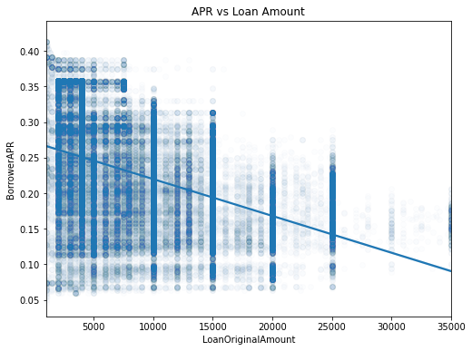

```python
plt.figure(figsize = [8, 6])
sb.regplot(data = loan_sub, x = 'LoanOriginalAmount', y = 'BorrowerAPR', scatter_kws={'alpha':0.01})
plt.title('APR vs Loan Amount');
```

### Some of the relationships I observed in this part of the investigation.

> - The loan borrowers APR is negatively corrolated with the loan amount. ie. the more the loan amount the lesser the borrowers APR. However, for different range of loan amount there is a wide range of APR
> - The lower the prosper score the higher the APR

### Some interesting relationships I observerd between the other features

> - The longer the loan term the more the loan amount
> - The higer the prosper score the higer the monthly income
> - There is a positve corrolation between monthly income and loan amount

## Multivariate Exploration

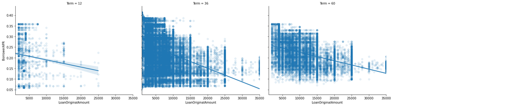

```python
# Term effect on relationship of APR and loan amount
g=sb.FacetGrid(data=loan_sub, aspect=1.2, height=5, col='Term', col_wrap=4)
g.map(sb.regplot, 'LoanOriginalAmount', 'BorrowerAPR', x_jitter=0.04, scatter_kws={'alpha':0.1});
g.add_legend();
```

- Term seem not affect the rationship between loan amount and APR

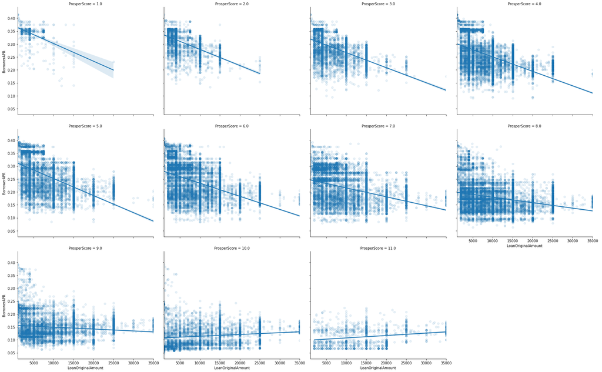

```python
# Prosper rating effect on relationship of APR and loan amount
g=sb.FacetGrid(data=loan_sub, aspect=1.2, height=5, col='ProsperScore', col_wrap=4)
g.map(sb.regplot, 'LoanOriginalAmount', 'BorrowerAPR', x_jitter=0.04, scatter_kws={'alpha':0.1});
g.add_legend();
```

- Interestingly, as the prosper score gets better the relationship between the loan amount and APR changes from negative to slightly positive
- Borrowers with low prosper score have higher APR and less loan amount

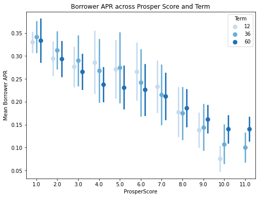

```python
fig = plt.figure(figsize = [8,6])
ax = sb.pointplot(data = loan_sub, x = 'ProsperScore', y = 'BorrowerAPR', hue = 'Term',
           palette = 'Blues', linestyles = '', dodge = 0.4, ci='sd')
plt.title('Borrower APR across Prosper Score and Term')
plt.ylabel('Mean Borrower APR')
ax.set_yticklabels([],minor = True);
```

### Some of the relationships I observed in this part of the investigation.

> - As the prosper score gets better the relationship between the loan amount and APR changes from negative to slightly positive
> - Borrowers with lower prosper score tend to have higher APR and less loan amount

## Conclusions

The above analysis reveals some very interestng insights. Below are some key insights particularly related to my feature of interest- BorrowersAPR

> - The lower the prosper score the higher the APR
> - As the prosper score gets better the relationship between the loan amount and APR changes from negative to slightly positive
> - Borrowers with low prosper score have higher APR and less loan amount
> - The borrowers APR is generally negatively corrolated with the loan amount. ie. the more the loan amount the lesser the borrowers APR. However, for different range of loan amount there is a wide range of APR
> - The lower the prosper score the higher the APR